# Principal Componants

Martha Richards

# **What is Principal Component Analysis?**

Principal Component Analysis (PCA) is a method of reducing large data sets into fewer variables yet keeping the key data trends. PCA identifies uncorrelated ocmponents which capture the most variance, which simplifies the data and males analysis faster and more efficient.

## Why do we need PCA?

We need to visualise data, but we cannot visualise all variables at once. We could pick two and plot them against each other, but we would lose the information from all the other variables that might influence the outcome. PCA solves this by taking all the variables, combines them, and producing new variables which are called principal components (PCs). The first few PCs contains most of the information in the data set, and PCs are ranked from most to least important.

## What is dimensionality reduction?

PCA is a linear dimensionality reduction algorithm. This means the data is transformed from data with high-dimensional space (many columns/variables) into a low dimensional space, while preserving as much of the original data as possible. There are three common dimensionality reduction algorithms: PCA, tSNE and UMAP.

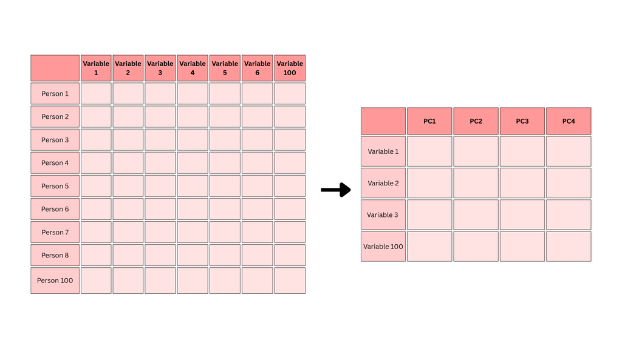